# Kyphosis Exploratory Data Analysis

Lohit Marla

2023-11-11

# Introduction

The Kyphosis dataset is related to a medical condition called kyphosis, a spinal disorder characterized by an abnormal outward curvature of the spine. This dataset is often used for binary classification and predictive modeling.

## Dataset Overview

Let’s take a look at the key variables in the dataset:

- **Kyphosis:** A binary variable indicating the presence or absence of the kyphosis condition, coded as “present” or “absent.”
- **Age:** The age of the patient.
- **Number:** The number of vertebrae involved in the operation.
- **Start:** The starting vertebrae of the operation.

**The goal is to model the binary response Kyphosis, which indicates if a kyphosis (a type of deformation) was present or absent after the operation.**

# Data Exploration

```r
library("rpart")
library(caret)
kyphosis.data_tmp <- rpart::kyphosis
kyphosis.data <- kyphosis.data_tmp
str(kyphosis)
```

```
## 'data.frame':    81 obs. of  4 variables:
##  $ Kyphosis: Factor w/ 2 levels "absent","present": 1 1 2 1 1 1 1 1 1 2 ...
##  $ Age     : int  71 158 128 2 1 1 61 37 113 59 ...
##  $ Number  : int  3 3 4 5 4 2 2 3 2 6 ...
##  $ Start   : int  5 14 5 1 15 16 17 16 16 12 ...
```

```r
#converting the values of kyphosis variable to 1 or 0 from absent or present
kyphosis.data$Kyphosis <- ifelse(tolower(kyphosis.data$Kyphosis) == "present", 1, 0)
```

We can observe total of 81 observations and 4 variables out of which Kyphosis variable is the response variables where as the Age, Number and Start are the parameters/features/predictors.

Following is the code to split the train and test data based on the 90-10 proportions

```r
set.seed(123457)
train.prop <- 0.90
strats <- kyphosis.data$Kyphosis
rr <- split(1:length(strats), strats)
idx <- sort(as.numeric(unlist(sapply(rr,
        function(x) sample(x, length(x)*train.prop)))))
kyphosis.data.train <- kyphosis.data[idx, ]
kyphosis.data.test <- kyphosis.data[-idx, ]

nrow(kyphosis.data.train) #72
```

```
## [1] 72
```

```r
nrow(kyphosis.data.test)  #09
```

```
## [1] 9
```

```r
indices <- which(kyphosis.data.train$Kyphosis == 1)
subset_data <- kyphosis.data.train[indices, ]
n_1s <- nrow(subset_data) / nrow(kyphosis.data.train)
indices <- which(kyphosis.data.train$Kyphosis == 0)
subset_data <- kyphosis.data.train[indices, ]
n_0s <- nrow(subset_data) / nrow(kyphosis.data.train)
print("proportions of 1's and 0's in train data set")
```

```
## [1] "proportions of 1's and 0's in train data set"
```

```r
print(n_1s)
```

```
## [1] 0.2083333
```

```r
print(n_0s)
```

```
## [1] 0.7916667
```

```r
indices <- which(kyphosis.data.test$Kyphosis == 1)
subset_data <- kyphosis.data.test[indices, ]
n_1s <- nrow(subset_data) / nrow(kyphosis.data.test)
indices <- which(kyphosis.data.test$Kyphosis == 0)
subset_data <- kyphosis.data.test[indices, ]
n_0s <- nrow(subset_data) / nrow(kyphosis.data.test)
print("proportions of 1's and 0's in test data set")
```

```
## [1] "proportions of 1's and 0's in test data set"
```

```r
print(n_1s)
```

```
## [1] 0.2222222
```

```r
print(n_0s)
```

```
## [1] 0.7777778
```

```r
indices <- which(kyphosis.data_tmp$Kyphosis == 'present')
subset_data <- kyphosis.data_tmp[indices, ]
n_1s <- nrow(subset_data) / nrow(kyphosis.data_tmp)
indices <- which( kyphosis.data_tmp$Kyphosis == 'absent')
subset_data <- kyphosis.data_tmp[indices, ]
n_0s <- nrow(subset_data) / nrow(kyphosis.data_tmp)
print("proportions of 1's and 0's in test data set")
```

```
## [1] "proportions of 1's and 0's in test data set"
```

```r
print(n_1s)
```

```
## [1] 0.2098765
```

```r
print(n_0s)
```

```
## [1] 0.7901235
```

Following is the reason for the having similar proportions of the train, test and split datasets

**Maintaining Representative Samples:** If our dataset has an imbalanced distribution of the response variable, meaning one class is significantly more frequent than the other, a random split may result in an imbalanced distribution in the training and testing sets. This can lead to biased model performance metrics. By ensuring a similar proportion in both sets, we obtain more representative samples.

**Avoiding Sampling Bias:** Imbalanced datasets can introduce bias in the model learning process. For example, if the training set has a much higher proportion of one class, the model may become overly biased towards that class, leading to poor generalization on the test set.

**Real-world Generalization:** The goal of a predictive model is often to make accurate predictions on new, unseen data. If the test set does not reflect the distribution of the response variable in the real world, the model’s performance on the test set may not accurately represent its performance in practice.

Below is the code to fit the Kyphosis.full.logit on the train dataset

```r
Kyphosis.full.logit <- glm(Kyphosis ~ . ,data = kyphosis.data.train,
                  family = binomial(link = "logit"))
summary(Kyphosis.full.logit)
```

```
##
## Call:
## glm(formula = Kyphosis ~ ., family = binomial(link = "logit"),
##     data = kyphosis.data.train)
##
## Coefficients:
##              Estimate Std. Error z value Pr(>|z|)
## (Intercept) -1.047104   1.584372  -0.661  0.50868
## Age          0.009606   0.007057   1.361  0.17343
## Number       0.317924   0.237262   1.340  0.18026
## Start       -0.260587   0.079381  -3.283  0.00103 **
## ---
## Signif. codes:  0 '***' 0.001 '**' 0.01 '*' 0.05 '.' 0.1 ' ' 1
##
## (Dispersion parameter for binomial family taken to be 1)
##
##     Null deviance: 73.691  on 71  degrees of freedom
## Residual deviance: 50.402  on 68  degrees of freedom
## AIC: 58.402
##
## Number of Fisher Scoring iterations: 5
```

From the above summary we can interpret that Start predictor variable is having significant impact on the response variable and for each one-unit increase in Start, the estimated log-odds of kyphosis decreases by 0.260587, assuming the other predictors are held constant. Exp of −0.260587 is 0.770 which is that the multiplicative effect on expected count due to a unit increase in Start is 0.770.

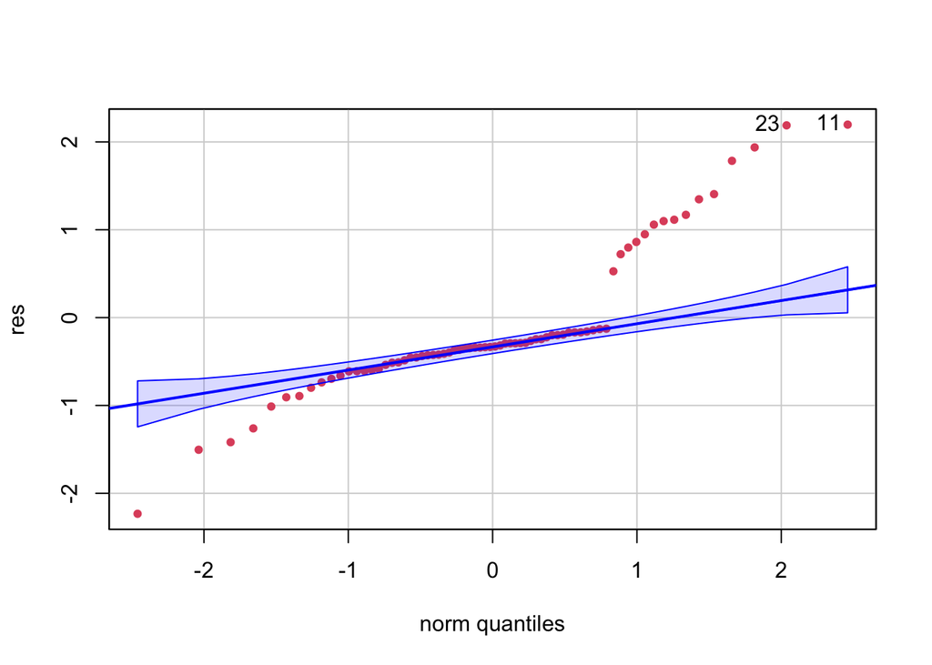

```
## 11 23
##  9 21
```

```r
library(e1071)
res <- residuals(Kyphosis.full.logit)
car::qqPlot(res, main = NA, pch = 19, col = 2, cex = 0.7)
```

From the residual plot we can observe that there are data points which are outliers

```r
Kyphosis.null.logit <- glm(Kyphosis ~ 1 ,data = kyphosis.data.train,
                  family = binomial(link = "logit"))
summary(Kyphosis.null.logit)
```

```
##
## Call:
## glm(formula = Kyphosis ~ 1, family = binomial(link = "logit"),
##     data = kyphosis.data.train)
##
## Coefficients:
##             Estimate Std. Error z value Pr(>|z|)
## (Intercept)  -1.3350     0.2902    -4.6 4.22e-06 ***
## ---
## Signif. codes:  0 '***' 0.001 '**' 0.01 '*' 0.05 '.' 0.1 ' ' 1
##
## (Dispersion parameter for binomial family taken to be 1)
##
##     Null deviance: 73.691  on 71  degrees of freedom
## Residual deviance: 73.691  on 71  degrees of freedom
## AIC: 75.691
##
## Number of Fisher Scoring iterations: 4
```

```r
Kyphosis.null.logit.predict.test <- predict(Kyphosis.null.logit, newdata = kyphosis.data.test, type="response")

#Kyphosis.full.logit.predict.test
b <- ifelse(Kyphosis.null.logit.predict.test > 0.5,1,0)
cm.both <- confusionMatrix(reference=as.factor(kyphosis.data.test$Kyphosis),
            data=as.factor(b), mode="everything")
cm.both
```

```
## Confusion Matrix and Statistics
##
##           Reference
## Prediction 0 1
##          0 7 2
##          1 0 0
##
##                Accuracy : 0.7778
##                  95% CI : (0.3999, 0.9719)
##     No Information Rate : 0.7778
##     P-Value [Acc > NIR] : 0.6781
##
##                   Kappa : 0
##
##  Mcnemar's Test P-Value : 0.4795
##
##             Sensitivity : 1.0000
##             Specificity : 0.0000
##          Pos Pred Value : 0.7778
##          Neg Pred Value :    NaN
##               Precision : 0.7778
##                  Recall : 1.0000
##                      F1 : 0.8750
##              Prevalence : 0.7778
##          Detection Rate : 0.7778
##    Detection Prevalence : 1.0000
##       Balanced Accuracy : 0.5000
##
##        'Positive' Class : 0
##
```

```r
Kyphosis.null.logit.predict.train <- predict(Kyphosis.null.logit, newdata = kyphosis.data.train, type="response")

#Kyphosis.full.logit.predict.train
b <- ifelse(Kyphosis.null.logit.predict.train > 0.5,1,0)
cm.both <- confusionMatrix(reference=as.factor(kyphosis.data.train$Kyphosis),
            data=as.factor(b), mode="everything")
cm.both
```

```
## Confusion Matrix and Statistics
##
##           Reference
## Prediction  0  1
##          0 57 15
##          1  0  0
##
##                Accuracy : 0.7917
##                  95% CI : (0.6798, 0.8784)
##     No Information Rate : 0.7917
##     P-Value [Acc > NIR] : 0.5685560
##
##                   Kappa : 0
##
##  Mcnemar's Test P-Value : 0.0003006
##
##             Sensitivity : 1.0000
##             Specificity : 0.0000
##          Pos Pred Value : 0.7917
##          Neg Pred Value :    NaN
##               Precision : 0.7917
##                  Recall : 1.0000
##                      F1 : 0.8837
##              Prevalence : 0.7917
##          Detection Rate : 0.7917
##    Detection Prevalence : 1.0000
##       Balanced Accuracy : 0.5000
##
##        'Positive' Class : 0
##
```

AIC value of full model is 58.402 where as the null model is 75.691.

**Akaike Information Criterion:** We can also compare the Akaike Information Criterion (AIC) from the fitted full model and the null model.

AIC is an information criterion used for model selection.

From the above description the better model is the one which gives the smaller AIC, here the full model with AIC = 58.402 value

Following is the residual plot of the null logit model

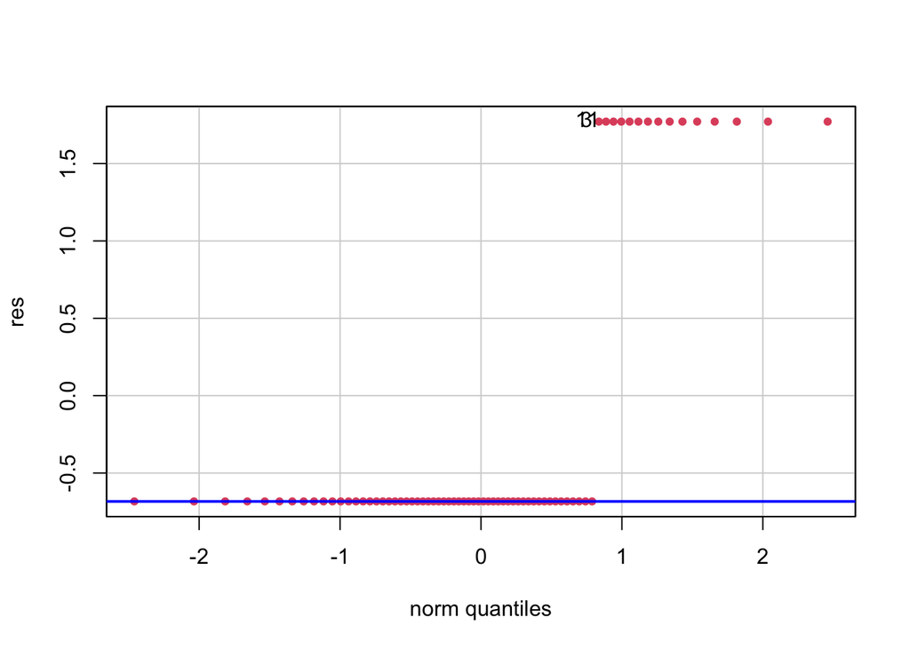

```
##  3 11
##  3  9
```

```r
library(e1071)
res <- residuals(Kyphosis.null.logit)
car::qqPlot(res, main = NA, pch = 19, col = 2, cex = 0.7)
```

**ROC curve**. Another useful metric is area under the receiver operating characteristics (ROC) curve. The ROC curve is a metric used to evaluate the prediction accuracy in binary and multi-class classification. It quantifies the trade-off between the sensitivity or true positive rate (TPR) and specificity or false positive rate (FPR) of a prediction.

**The area under the curve (AUC)** is a common metric used to evaluate the performance of binary classification models. It represents the area under the receiver operating characteristic (ROC) curve, which is a graphical representation of the true positive rate (sensitivity) against the false positive rate (1-specificity) at various thresholds.

```r
library(pROC)
Kyphosis.full.logit.predict.test <- predict(Kyphosis.full.logit, newdata = kyphosis.data.test, type="response")
Kyphosis.null.logit.predict <- predict(Kyphosis.null.logit, newdata = kyphosis.data.test, type="response")

roc.both.full <- roc(kyphosis.data.test$Kyphosis, Kyphosis.full.logit.predict.test, levels=c(1,0))
roc.both.full
```

```
##
## Call:
## roc.default(response = kyphosis.data.test$Kyphosis, predictor = Kyphosis.full.logit.predict.test,     levels = c(1, 0))
##
## Data: Kyphosis.full.logit.predict.test in 2 controls (kyphosis.data.test$Kyphosis 1) > 7 cases (kyphosis.data.test$Kyphosis 0).
## Area under the curve: 0.5714
```

```r
roc.both.null <- roc(kyphosis.data.test$Kyphosis, Kyphosis.null.logit.predict, levels=c(1,0))
roc.both.null
```

```
##
## Call:
## roc.default(response = kyphosis.data.test$Kyphosis, predictor = Kyphosis.null.logit.predict,     levels = c(1, 0))
##
## Data: Kyphosis.null.logit.predict in 2 controls (kyphosis.data.test$Kyphosis 1) < 7 cases (kyphosis.data.test$Kyphosis 0).
## Area under the curve: 0.5
```

We choose the model which is having moer AOC value and here we can observe the full model when tested on the test dataset the roc curve for it around 0.5714 whereas for the null model it is 0.5 which is less when compared to the full model.

However, both AUC values are relatively low, indicating that these models may not be effective in discriminating between positive and negative cases.

The directionality suggests that both models are setting the threshold in a way that prioritizes controls (non-kyphosis cases) over cases (kyphosis cases).

In practice, an AUC closer to 1 indicates better discrimination, while an AUC closer to 0.5 suggests poor discrimination or performance similar to random chance.

```r
library(pROC)

Kyphosis.full.logit.predict.train <- predict(Kyphosis.full.logit, newdata = kyphosis.data.train, type="response")
Kyphosis.null.logit.predict <- predict(Kyphosis.null.logit, newdata = kyphosis.data.train, type="response")

roc.both.full <- roc(kyphosis.data.train$Kyphosis, Kyphosis.full.logit.predict.train, levels=c(1,0))
roc.both.full
```

```
##
## Call:
## roc.default(response = kyphosis.data.train$Kyphosis, predictor = Kyphosis.full.logit.predict.train,     levels = c(1, 0))
##
## Data: Kyphosis.full.logit.predict.train in 15 controls (kyphosis.data.train$Kyphosis 1) > 57 cases (kyphosis.data.train$Kyphosis 0).
## Area under the curve: 0.8819
```

```r
roc.both.null <- roc(kyphosis.data.train$Kyphosis, Kyphosis.null.logit.predict, levels=c(1,0))
roc.both.null
```

```
##
## Call:
## roc.default(response = kyphosis.data.train$Kyphosis, predictor = Kyphosis.null.logit.predict,     levels = c(1, 0))
##
## Data: Kyphosis.null.logit.predict in 15 controls (kyphosis.data.train$Kyphosis 1) < 57 cases (kyphosis.data.train$Kyphosis 0).
## Area under the curve: 0.5
```

We can apply the step wise variable selection method to know the variables which are showing significant impact on the response variable

```r
both.logit <- step(Kyphosis.full.logit,
                   direction="both",trace=0, data = kyphosis.data.train)
formula(both.logit)
```

```
## Kyphosis ~ Number + Start
```

```r
summary(both.logit)
```

```
##
## Call:
## glm(formula = Kyphosis ~ Number + Start, family = binomial(link = "logit"),
##     data = kyphosis.data.train)
##
## Coefficients:
##             Estimate Std. Error z value Pr(>|z|)
## (Intercept) -0.26538    1.37633  -0.193  0.84710
## Number       0.29835    0.21698   1.375  0.16912
## Start       -0.24274    0.07525  -3.226  0.00126 **
## ---
## Signif. codes:  0 '***' 0.001 '**' 0.01 '*' 0.05 '.' 0.1 ' ' 1
##
## (Dispersion parameter for binomial family taken to be 1)
##
##     Null deviance: 73.691  on 71  degrees of freedom
## Residual deviance: 52.376  on 69  degrees of freedom
## AIC: 58.376
##
## Number of Fisher Scoring iterations: 5
```

Intercept: -0.26538

This is the log-odds of the baseline category when both Number and Start are zero. Number: 0.29835

For a one-unit increase in Number, the log-odds of the response variable (Kyphosis) increases by 0.29835, assuming Start is held constant. Start: -0.24274

For a one-unit increase in Start, the log-odds of the response variable (Kyphosis) decreases by 0.24274, assuming Number is held constant. The significance codes indicate the level of significance for each coefficient. In our output, Start has a low p-value (0.00126), suggesting that it is likely to be a significant predictor.

The deviance values provide information about the goodness of fit of the model. The AIC (Akaike Information Criterion) is a measure of the model’s goodness of fit while penalizing for the number of parameters.

The logit of the probability of the presence of Kyphosis is represented by the linear combination of the intercept and the coefficients of the predictor variables in the logistic regression model. The logit function is defined as the natural logarithm of the odds ratio.

```r
library(pROC)

both.logit.predict.test <- predict(both.logit, newdata = kyphosis.data.test, type="response")
(table.both.backward <- table(both.logit.predict.test > 0.5, kyphosis.data.test$Kyphosis))
```

```
##
##         0 1
##   FALSE 6 2
##   TRUE  1 0
```

```r
(accuracy.both.backward <- round((sum(diag(table.both.backward))/sum(table.both.backward))*100,2))
```

```
## [1] 66.67
```

Accuracy of the step wise both model is around 66.67% on the test data.

**In the context of our logistic regression model:**

logit(Probability of Kyphosis)= Intercept+(Coefficient(Age) ×Age) + (Coefficient(Number) × Number) + (Coefficient(Start) × Start)

Mathematically, the logit function is represented as:

logit(p) = log(p/(1-p))

where p is the probability of the presence of Kyphosis.

In out case, the logit function for the logistic regression model would be:

logit(p)=−1.047104+(0.009606×Age)+(0.317924×Number)+(−0.260587×Start)

This logit function is used to calculate the log-odds of the presence of Kyphosis based on the values of the predictor variables. To obtain the probability, we can use the inverse logit function (also known as the logistic function

```r
logit_values <- predict(Kyphosis.full.logit, newdata = kyphosis.data.train, type = "link")
probabilities <- 1 / (1 + exp(-logit_values))
probabilities
```

```
##           1           2           3           5           6           7
## 0.328662691 0.097633715 0.537735237 0.024732092 0.010241176 0.013990753
##           8           9          11          12          13          14
## 0.019698773 0.029450042 0.089642318 0.055146723 0.548409937 0.052508185
##          15          16          17          18          19          20
## 0.040307104 0.014020414 0.091197708 0.237930237 0.054248917 0.134548026
##          21          22          23          25          26          27
## 0.012501605 0.637871230 0.091272284 0.690247627 0.059599179 0.170794376
##          28          29          30          31          32          33
## 0.058362415 0.014424422 0.041881079 0.018616047 0.111356495 0.168494794
##          35          37          38          39          40          41
## 0.273070793 0.080987011 0.372502812 0.215391786 0.153114249 0.727736351
##          42          43          44          45          46          47
## 0.041298471 0.917292133 0.634129048 0.034524859 0.203596789 0.084881747
##          49          50          51          52          53          54
## 0.571319529 0.086336782 0.196210983 0.008536902 0.870326573 0.007986169
##          55          56          58          59          60          61
## 0.087914416 0.064485415 0.403847872 0.336927883 0.075777659 0.770792066
##          62          63          64          65          66          67
## 0.547048702 0.677453311 0.041918173 0.056717117 0.098147613 0.048889909
##          68          70          71          72          73          74
## 0.163053618 0.029805910 0.169672442 0.156766389 0.042734361 0.400727356
##          75          76          78          79          80          81
## 0.019908998 0.121923466 0.123519604 0.066225841 0.504572888 0.056400452
```

The logit is the linear combination of the intercept and the coefficients of the predictor variables. In the context of our logistic regression model:

logit = Intercept+ ( Coefficient Age × Age ) + ( Coefficient Number × Number ) + ( Coefficient Start × Start )

```r
probabilities <- predict(Kyphosis.full.logit, newdata = kyphosis.data.train, type = "response")
probabilities
```

```
##           1           2           3           5           6           7
## 0.328662691 0.097633715 0.537735237 0.024732092 0.010241176 0.013990753
##           8           9          11          12          13          14
## 0.019698773 0.029450042 0.089642318 0.055146723 0.548409937 0.052508185
##          15          16          17          18          19          20
## 0.040307104 0.014020414 0.091197708 0.237930237 0.054248917 0.134548026
##          21          22          23          25          26          27
## 0.012501605 0.637871230 0.091272284 0.690247627 0.059599179 0.170794376
##          28          29          30          31          32          33
## 0.058362415 0.014424422 0.041881079 0.018616047 0.111356495 0.168494794
##          35          37          38          39          40          41
## 0.273070793 0.080987011 0.372502812 0.215391786 0.153114249 0.727736351
##          42          43          44          45          46          47
## 0.041298471 0.917292133 0.634129048 0.034524859 0.203596789 0.084881747
##          49          50          51          52          53          54
## 0.571319529 0.086336782 0.196210983 0.008536902 0.870326573 0.007986169
##          55          56          58          59          60          61
## 0.087914416 0.064485415 0.403847872 0.336927883 0.075777659 0.770792066
##          62          63          64          65          66          67
## 0.547048702 0.677453311 0.041918173 0.056717117 0.098147613 0.048889909
##          68          70          71          72          73          74
## 0.163053618 0.029805910 0.169672442 0.156766389 0.042734361 0.400727356
##          75          76          78          79          80          81
## 0.019908998 0.121923466 0.123519604 0.066225841 0.504572888 0.056400452
```

The resulting probabilities will contain the predicted probabilities of the presence of Kyphosis for each observation in our new data based on the logistic regression model. Each probability is between 0 and 1, indicating the likelihood of the presence of Kyphosis for the corresponding set of predictor variable values.

In the context of logistic regression, testing whether the regression coefficient for a predictor (e.g., Age) is significantly different from zero involves a Wald test. The Wald test is used to assess the statistical significance of individual coefficients in logistic regression.

** Hypothesis in Notation: **

Null Hypothesis($H_0$) - $H_0$ : $\beta_{age}$ = 0 (The coefficient for Age is not significantly different from zero.) Alternative Hypothesis($H_A$) - $H_A$ : $\beta_{age}$ $\neq$ 0 (The coefficient for Age is significantly different from zero.)

** Hypothesis in Word ** $H_0$ : There is no significant association between Age and the log-odds of the presence of Kyphosis. $H_A$ : There is a significant association between Age and the log-odds of the presence of Kyphosis.

** Test Statistic Formula ** The Wald test statistic for testing the significance of an individual coefficient is calculated using the formula:

$$z = \beta_{age} / SE_{\beta_{age}}$$
$\beta_{age}$ is the standard estimated co-efficient of age $SE_{\beta_{age}}$ is the standard error of the estimated coefficient for Age.

```r
summary_model <- summary(Kyphosis.full.logit)


beta_age <- summary_model$coefficients["Age", "Estimate"]
se_age <- summary_model$coefficients["Age", "Std. Error"]


# Calculate the Wald test statistic
wald_statistic <- beta_age / se_age

print(wald_statistic)
```

```
## [1] 1.36126
```

```r
# Obtain the p-value from the standard normal distribution
p_value <- 2 * (1 - pnorm(abs(wald_statistic)))

print(p_value)
```

```
## [1] 0.1734314
```

We see the p-value is greater than the significant level and confirms that we accept null hypothesis of there is no significant association between Age and the log-odds of the presence of Kyphosis.

Following is the code to fit the logit model for the age predictor

```r
Kyphosis.age.logit <- glm(Kyphosis ~ Age ,data = kyphosis.data.train,
                  family = binomial(link = "logit"))
summary(Kyphosis.age.logit)
```

```
##
## Call:
## glm(formula = Kyphosis ~ Age, family = binomial(link = "logit"),
##     data = kyphosis.data.train)
##
## Coefficients:
##              Estimate Std. Error z value Pr(>|z|)
## (Intercept) -1.744365   0.555998  -3.137   0.0017 **
## Age          0.004610   0.005076   0.908   0.3637
## ---
## Signif. codes:  0 '***' 0.001 '**' 0.01 '*' 0.05 '.' 0.1 ' ' 1
##
## (Dispersion parameter for binomial family taken to be 1)
##
##     Null deviance: 73.691  on 71  degrees of freedom
## Residual deviance: 72.854  on 70  degrees of freedom
## AIC: 76.854
##
## Number of Fisher Scoring iterations: 4
```

```r
#test data
Kyphosis.reduced.logit.predict.test <- predict(Kyphosis.age.logit, newdata = kyphosis.data.test, type="response")

roc.both.full <- roc(kyphosis.data.test$Kyphosis, Kyphosis.reduced.logit.predict.test, levels=c(1,0))
roc.both.full
```

```
##
## Call:
## roc.default(response = kyphosis.data.test$Kyphosis, predictor = Kyphosis.reduced.logit.predict.test,     levels = c(1, 0))
##
## Data: Kyphosis.reduced.logit.predict.test in 2 controls (kyphosis.data.test$Kyphosis 1) > 7 cases (kyphosis.data.test$Kyphosis 0).
## Area under the curve: 0.7143
```

```r
#train data
Kyphosis.reduced.logit.predict.train <- predict(Kyphosis.age.logit, newdata = kyphosis.data.train, type="response")

roc.both.full <- roc(kyphosis.data.train$Kyphosis, Kyphosis.reduced.logit.predict.train, levels=c(1,0))
roc.both.full
```

```
##
## Call:
## roc.default(response = kyphosis.data.train$Kyphosis, predictor = Kyphosis.reduced.logit.predict.train,     levels = c(1, 0))
##
## Data: Kyphosis.reduced.logit.predict.train in 15 controls (kyphosis.data.train$Kyphosis 1) > 57 cases (kyphosis.data.train$Kyphosis 0).
## Area under the curve: 0.5807
```

Following are the roc and auc values for both the models, Auc for the full model is 0.5714 where as the reduced model is 0.7143

Following is the code to calcualte the accuracy, sensitivity and specifivity of the both full model as well as the reduced model on both the train and test data.

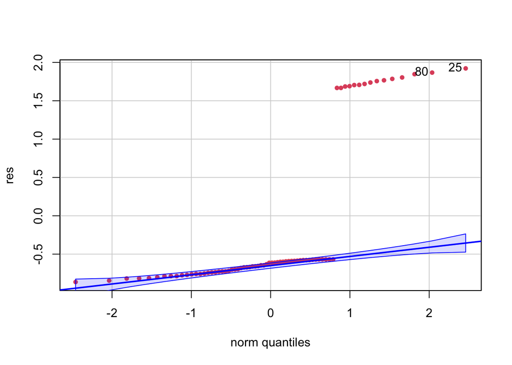

```
## 25 80
## 22 71
```

```r
library(e1071)
res <- residuals(Kyphosis.age.logit)
car::qqPlot(res, main = NA, pch = 19, col = 2, cex = 0.7)
```

We see most of the data points are normal except few for the reduced model where as we see more residuals for the full model which indicates the overfitting the age mdoel to the datapoints whereas the full model more of the generalised model.

```r
#accuracy calculation for both full model as well as the age model

#Kyphosis.full.logit.predict.test
b <- ifelse(Kyphosis.full.logit.predict.test > 0.5,1,0)
cm.both <- confusionMatrix(reference=as.factor(kyphosis.data.test$Kyphosis),
            data=as.factor(b), mode="everything")
cm.both
```

```
## Confusion Matrix and Statistics
##
##           Reference
## Prediction 0 1
##          0 5 2
##          1 2 0
##
##                Accuracy : 0.5556
##                  95% CI : (0.212, 0.863)
##     No Information Rate : 0.7778
##     P-Value [Acc > NIR] : 0.9696
##
##                   Kappa : -0.2857
##
##  Mcnemar's Test P-Value : 1.0000
##
##             Sensitivity : 0.7143
##             Specificity : 0.0000
##          Pos Pred Value : 0.7143
##          Neg Pred Value : 0.0000
##               Precision : 0.7143
##                  Recall : 0.7143
##                      F1 : 0.7143
##              Prevalence : 0.7778
##          Detection Rate : 0.5556
##    Detection Prevalence : 0.7778
##       Balanced Accuracy : 0.3571
##
##        'Positive' Class : 0
##
```

```r
#Kyphosis.full.logit.predict.train
b <- ifelse(Kyphosis.full.logit.predict.train > 0.5,1,0)
cm.both <- confusionMatrix(reference=as.factor(kyphosis.data.train$Kyphosis),
            data=as.factor(b), mode="everything")
cm.both
```

```
## Confusion Matrix and Statistics
##
##           Reference
## Prediction  0  1
##          0 53  6
##          1  4  9
##
##                Accuracy : 0.8611
##                  95% CI : (0.7594, 0.9313)
##     No Information Rate : 0.7917
##     P-Value [Acc > NIR] : 0.09162
##
##                   Kappa : 0.5572
##
##  Mcnemar's Test P-Value : 0.75183
##
##             Sensitivity : 0.9298
##             Specificity : 0.6000
##          Pos Pred Value : 0.8983
##          Neg Pred Value : 0.6923
##               Precision : 0.8983
##                  Recall : 0.9298
##                      F1 : 0.9138
##              Prevalence : 0.7917
##          Detection Rate : 0.7361
##    Detection Prevalence : 0.8194
##       Balanced Accuracy : 0.7649
##
##        'Positive' Class : 0
##
```

```r
#Kyphosis.reduced.logit.predict.test
b <- ifelse(Kyphosis.reduced.logit.predict.test > 0.5,1,0)
cm.both <- confusionMatrix(reference=as.factor(kyphosis.data.test$Kyphosis),
            data=as.factor(b), mode="everything")
cm.both
```

```
## Confusion Matrix and Statistics
##
##           Reference
## Prediction 0 1
##          0 7 2
##          1 0 0
##
##                Accuracy : 0.7778
##                  95% CI : (0.3999, 0.9719)
##     No Information Rate : 0.7778
##     P-Value [Acc > NIR] : 0.6781
##
##                   Kappa : 0
##
##  Mcnemar's Test P-Value : 0.4795
##
##             Sensitivity : 1.0000
##             Specificity : 0.0000
##          Pos Pred Value : 0.7778
##          Neg Pred Value :    NaN
##               Precision : 0.7778
##                  Recall : 1.0000
##                      F1 : 0.8750
##              Prevalence : 0.7778
##          Detection Rate : 0.7778
##    Detection Prevalence : 1.0000
##       Balanced Accuracy : 0.5000
##
##        'Positive' Class : 0
##
```

```r
#Kyphosis.reduced.logit.predict.train
b <- ifelse(Kyphosis.reduced.logit.predict.train > 0.5,1,0)
cm.both <- confusionMatrix(reference=as.factor(kyphosis.data.train$Kyphosis),
            data=as.factor(b), mode="everything")
cm.both
```

```
## Confusion Matrix and Statistics
##
##           Reference
## Prediction  0  1
##          0 57 15
##          1  0  0
##
##                Accuracy : 0.7917
##                  95% CI : (0.6798, 0.8784)
##     No Information Rate : 0.7917
##     P-Value [Acc > NIR] : 0.5685560
##
##                   Kappa : 0
##
##  Mcnemar's Test P-Value : 0.0003006
##
##             Sensitivity : 1.0000
##             Specificity : 0.0000
##          Pos Pred Value : 0.7917
##          Neg Pred Value :    NaN
##               Precision : 0.7917
##                  Recall : 1.0000
##                      F1 : 0.8837
##              Prevalence : 0.7917
##          Detection Rate : 0.7917
##    Detection Prevalence : 1.0000
##       Balanced Accuracy : 0.5000
##
##        'Positive' Class : 0
##
```

By the terms of the accuracy we can see the accuracy value of the full model is 55.56% where as the reduced model is 77.78%. Also, Sensitivity value looks good for the reduced model when compared to the full model.

By taking **roc, accuracy and sensitivity into the considerations we choose the reduced model** is a good one to choose. Where as **if we consider the AIC value we go with the full model** as prediction accuracy can be misleading as the test data is less and moreover the full model is more generalised than the reducued model.

Following is the code to fit the advanced classification and regression trees algorithms on the data

```r
Kyphosis.cart.model <- rpart(Kyphosis ~. , method = "class", data = kyphosis.data.train, control = rpart.control(minsplit = 1, cp = 0.001))

printcp(Kyphosis.cart.model)
```

```
##
## Classification tree:
## rpart(formula = Kyphosis ~ ., data = kyphosis.data.train, method = "class",
##     control = rpart.control(minsplit = 1, cp = 0.001))
##
## Variables actually used in tree construction:
## [1] Age    Number Start
##
## Root node error: 15/72 = 0.20833
##
## n= 72
##
##         CP nsplit rel error  xerror    xstd
## 1 0.333333      0  1.000000 1.00000 0.22973
## 2 0.133333      1  0.666667 0.80000 0.21082
## 3 0.066667      3  0.400000 0.86667 0.21759
## 4 0.044444      4  0.333333 0.93333 0.22388
## 5 0.033333      7  0.200000 1.00000 0.22973
## 6 0.022222     11  0.066667 1.06667 0.23518
## 7 0.001000     14  0.000000 1.13333 0.24024
```

From the above summary we can interpret the following results, root node error is 20% which implies total root node error is the percent of incorrectly sorted cases at the first (root) splitting node.

Variables used in the tree construction is Age, Number and Start

**Root Node:** The first row with 1 is the root node, which is the topmost node in the decision tree. This is where the tree begins, and it represents the entire dataset before any splits.

**Internal Nodes:** Subsequent rows with numbers like 2, 3, 4, 5, and 6 represent internal nodes. Internal nodes are decision points where the dataset is split based on a specific condition.

**Leaf Nodes:** The row with the number 7 represents a leaf node. Leaf nodes are the terminal nodes where the final prediction or decision is made. Each leaf node corresponds to a subset of the data and typically provides the predicted outcome.

Cp is the complexity parameter, which is the sum of the error(fraction of misclassified cases) and number of leaf nodes in the tree

**rel error (Relative Error):** Represents the relative error at that node, which is a measure of the impurity or variability of the data. We can onserve that the number got decreased from 1.000 to 0.000 which indicates that the model got adjusted or fitted with the data which is an indication of the overfitting.

**xerror (Cross-validated Error):** Represents the cross-validated error, an estimate of the error rate on new, unseen data. We see the data got decreaed and increased from top to bottom. Best split would be the min value of the xerror.

**xstd (Cross-validated Standard Deviation):** Represents the standard deviation of the cross-validated error

Fitting the model on the test data

```r
pred <- predict(Kyphosis.cart.model, newdata = kyphosis.data.test, type = "class")
(conf_matrix_base <- table(kyphosis.data.test$Kyphosis, pred)) #confusion matrix
```

```
##    pred
##     0 1
##   0 5 2
##   1 2 0
```

```r
sensitivity(conf_matrix_base)
```

```
## [1] 0.7142857
```

```r
specificity(conf_matrix_base)
```

```
## [1] 0
```

```r
(mis.rate <- conf_matrix_base[1, 2] +
   conf_matrix_base[2, 1])/sum(conf_matrix_base)
```

```
## [1] 0.4444444
```

Sensitivity of the model is 0.71% where as the specifivity of the model is around 0 and misclassification of the model on the test dataset is around 44%.

```r
pred <- predict(Kyphosis.cart.model, newdata = kyphosis.data.train, type = "class")
(conf_matrix_base <- table(kyphosis.data.train$Kyphosis, pred)) #confusion matrix
```

```
##    pred
##      0  1
##   0 57  0
##   1  0 15
```

```r
sensitivity(conf_matrix_base)
```

```
## [1] 1
```

```r
specificity(conf_matrix_base)
```

```
## [1] 1
```

```r
(mis.rate <- conf_matrix_base[1, 2] +
   conf_matrix_base[2, 1])/sum(conf_matrix_base)
```

```
## [1] 0
```

If we test the train data accuracy we see all the data was perfectly predicted as the model got fitted with the data.

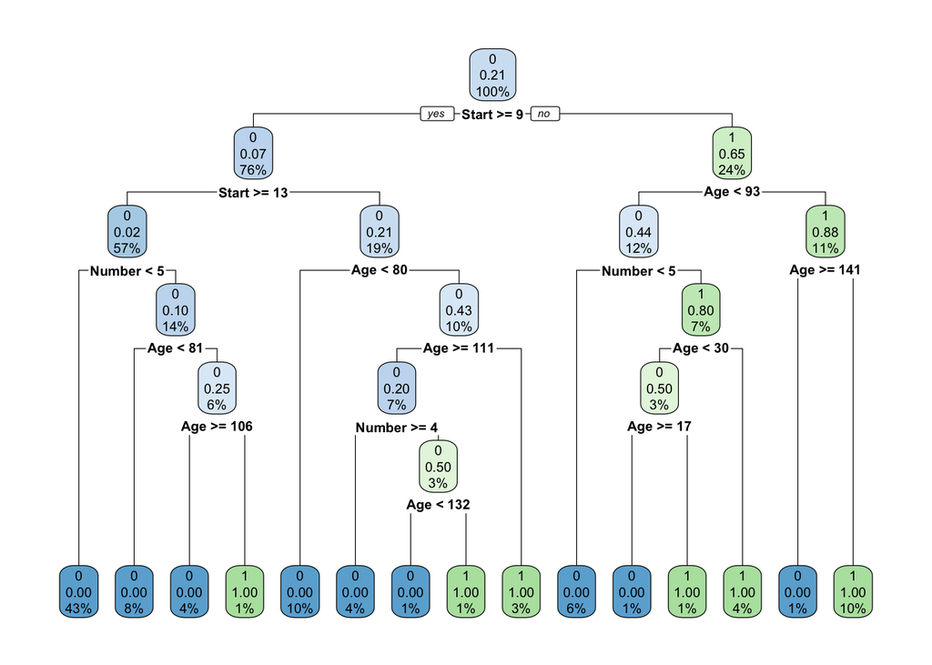

```r
library(rpart.plot)
rpart.plot(Kyphosis.cart.model, extra = "auto")
```

Following is the code to fit the random forest model on the train data

```r
library("ranger")
fit.rf.ranger <- ranger(Kyphosis ~ ., data = kyphosis.data.train,
                   importance = 'impurity', mtry = 3)
print(fit.rf.ranger)
```

```
## Ranger result
##
## Call:
##  ranger(Kyphosis ~ ., data = kyphosis.data.train, importance = "impurity",      mtry = 3)
##
## Type:                             Regression
## Number of trees:                  500
## Sample size:                      72
## Number of independent variables:  3
## Mtry:                             3
## Target node size:                 5
## Variable importance mode:         impurity
## Splitrule:                        variance
## OOB prediction error (MSE):       0.1169725
## R squared (OOB):                  0.3006279
```

From the above results, we can interpert the following results

## Interpretation

#### Number of Trees and Sample Size

The random forest model consists of 500 decision trees, and it was trained on a dataset with 72 observations and 3 predictor variables.

#### Model Complexity

The Mtry parameter, set to 3, indicates that 3 variables were considered for splitting at each tree node. This helps control the model’s complexity.

#### Variable Importance

Variable importance was calculated using the “Impurity” method, which measures the reduction in variance. This provides insights into the contribution of each predictor variable to the model’s predictive performance.

## Conclusion

The Random Forest regression model, with its ensemble of 500 trees, demonstrates reasonable predictive performance on the given dataset. The out-of-bag mean squared error and R squared values provide insights into the accuracy and explanatory power of the model.

```r
library(vip)
(v1 <- vi(fit.rf.ranger))
```

```
## # A tibble: 3 × 2
##   Variable Importance
##   <chr>         <dbl>
## 1 Start          5.31
## 2 Age            3.47
## 3 Number         1.56
```

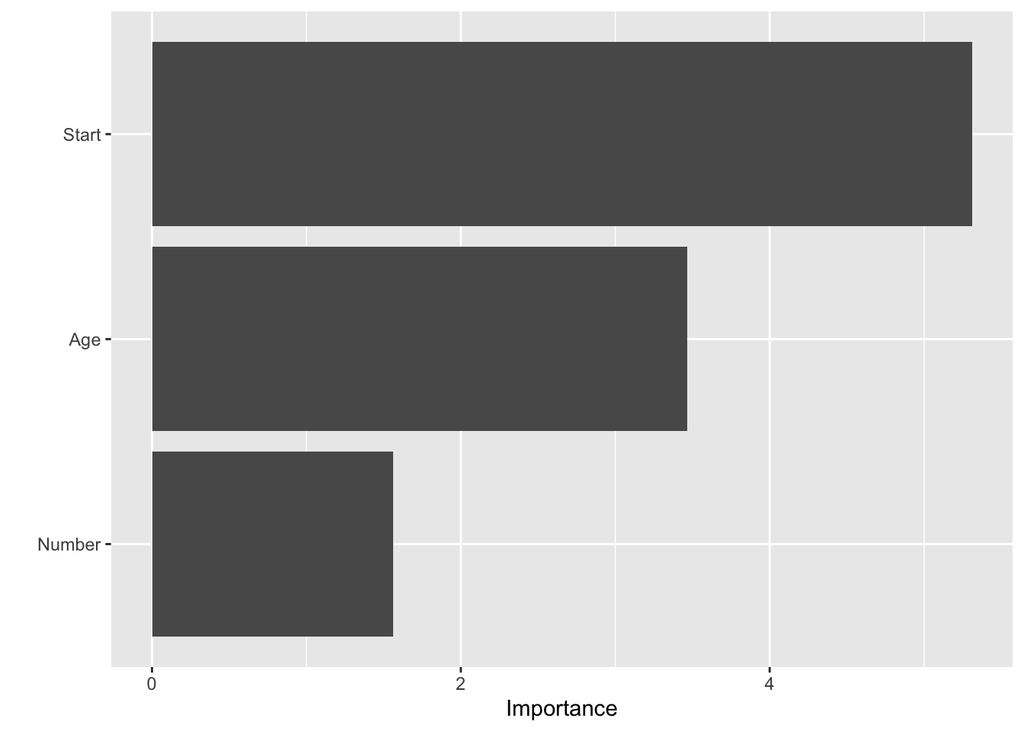

```r
vip(v1)
```

For each variable, we can use the above table and Figure to see how important it is in classifying the data. The vip plot shows the variables from high to low importance.

```r
pred <- predict(fit.rf.ranger, data = kyphosis.data.test)
conf_matrix_base <- table(kyphosis.data.test$Kyphosis, pred$predictions) #confusion matrix
b <- ifelse(pred$predictions > 0.5,1,0)
cm.both <- confusionMatrix(reference=as.factor(kyphosis.data.test$Kyphosis),
            data=as.factor(b), mode="everything")
cm.both
```

```
## Confusion Matrix and Statistics
##
##           Reference
## Prediction 0 1
##          0 6 2
##          1 1 0
##
##                Accuracy : 0.6667
##                  95% CI : (0.2993, 0.9251)
##     No Information Rate : 0.7778
##     P-Value [Acc > NIR] : 0.8822
##
##                   Kappa : -0.1739
##
##  Mcnemar's Test P-Value : 1.0000
##
##             Sensitivity : 0.8571
##             Specificity : 0.0000
##          Pos Pred Value : 0.7500
##          Neg Pred Value : 0.0000
##               Precision : 0.7500
##                  Recall : 0.8571
##                      F1 : 0.8000
##              Prevalence : 0.7778
##          Detection Rate : 0.6667
##    Detection Prevalence : 0.8889
##       Balanced Accuracy : 0.4286
##
##        'Positive' Class : 0
##
```

```r
(mis.rate <- conf_matrix_base[1, 2] +
   conf_matrix_base[2, 1])/sum(conf_matrix_base)
```

```
## [1] 0
```

Following is the code to apply XGBooost alogrithm on the Kyphosis train dataset. XGBooost needs a seperate setup to run the model where it expected the data in the matix format and so we convert the data into the matrix format.

```r
library(xgboost)
library(Matrix)

# Transform the predictor matrix using dummy (or indictor or one-hot) encoding
matrix_predictors.train <-
  as.matrix(sparse.model.matrix(Kyphosis ~., data = kyphosis.data.train))[, -1]
matrix_predictors.test <-
  as.matrix(sparse.model.matrix(Kyphosis ~., data = kyphosis.data.test))[, -1]

# Train dataset
pred.train.gbm <- data.matrix(matrix_predictors.train) # predictors only
#convert factor to numeric
kyphosis.data.train.gbm <- as.numeric(as.character(kyphosis.data.train$Kyphosis))
dtrain <- xgb.DMatrix(data = pred.train.gbm, label = kyphosis.data.train.gbm)
# Test dataset
pred.test.gbm <- data.matrix(matrix_predictors.test) # predictors only
 #convert factor to numeric
kyphosis.data.test.gbm <- as.numeric(as.character(kyphosis.data.test$Kyphosis))
dtest <- xgb.DMatrix(data = pred.test.gbm, label = kyphosis.data.test.gbm)

watchlist <- list(train = dtrain, test = dtest)
param <- list(max_depth = 2, eta = 1, nthread = 2,
              objective = "binary:logistic", eval_metric = "auc")
```

```r
model.xgb2 <- xgb.train(param, dtrain, nrounds = 2, watchlist)
pred.y.test <- predict(model.xgb2, pred.test.gbm)
prediction.test <- as.numeric(pred.y.test > 0.5)
# Measure prediction accuracy on train data
(tab<-table(kyphosis.data.test.gbm, prediction.test))
```

```
##                       prediction.test
## kyphosis.data.test.gbm 0 1
##                      0 6 1
##                      1 2 0
```

```r
sum(diag(tab))/sum(tab)
```

```
## [1] 0.6666667
```

```r
library("DiagrammeR")
xgb.plot.tree(model = model.xgb2, trees = 1, features_names = colnames(pred.train.gbm))
```

[interactive chart not shown]

# Effects of Increasing Number of Rounds in XGBoost

## Positive Effects

### Improved Performance

Increasing the number of rounds in the XGBoost model allows for capturing more complex patterns in the data. This often results in improved performance, as the model can better fit the training data.

### Better Generalization

A higher number of rounds may contribute to better generalization of the model to unseen data. This can help reduce overfitting and enhance the model’s ability to make accurate predictions on new, previously unseen instances.

## Negative Effects

### Overfitting

However, it’s crucial to be cautious with the number of rounds. If the value is set too high, the model may start memorizing the training data, leading to overfitting. This is particularly relevant when working with small datasets.

### Increased Training Time

As the number of rounds increases, training time tends to grow. Very high numbers of rounds can make training time impractical, especially when dealing with large datasets. It’s important to strike a balance between model complexity and computational efficiency.

```r
model.xgb8 <- xgb.train(param, dtrain, nrounds = 8, watchlist)
model.xgb8
```

```
## ##### xgb.Booster
## raw: 10.8 Kb
## call:
##   xgb.train(params = param, data = dtrain, nrounds = 8, watchlist = watchlist)
## params (as set within xgb.train):
##   max_depth = "2", eta = "1", nthread = "2", objective = "binary:logistic", eval_metric = "auc", validate_parameters = "TRUE"
## xgb.attributes:
##   niter
## callbacks:
##   cb.print.evaluation(period = print_every_n)
##   cb.evaluation.log()
## # of features: 3
## niter: 8
## nfeatures : 3
## evaluation_log:
##     iter train_auc  test_auc
##        1 0.8321637 0.3571429
##        2 0.9345029 0.3571429
## ---
##        7 0.9865497 0.4285714
##        8 0.9923977 0.4285714
```

```r
library("DiagrammeR")
xgb.plot.tree(model = model.xgb8, trees = 1, features_names = colnames(pred.train.gbm))
```

[interactive chart not shown]

from the above tree diagram we can observe that the splits at each step with the values of root node and leaf nodes.

```r
pred.y.test <- predict(model.xgb8, pred.test.gbm)
prediction.test <- as.numeric(pred.y.test > 0.5)
# Measure prediction accuracy on train data
(tab<-table(kyphosis.data.test.gbm, prediction.test))
```

```
##                       prediction.test
## kyphosis.data.test.gbm 0 1
##                      0 5 2
##                      1 2 0
```

```r
sum(diag(tab))/sum(tab)
```

```
## [1] 0.5555556
```

The prediction results of the test data by fitting the xgboost model and we can observe that the accurcy is 55% for the 8 number of rounds.

# Model Comparison for Kyphosis Dataset

Upon fitting the test data for the Kyphosis dataset, the following models were evaluated based on their respective accuracies:

1. **Full Logit Model:** 55%
   - The full logistic regression model achieved an accuracy of 55%.
2. **Null Logit Model:** 77%
   - Surprisingly, the null logistic regression model, which includes no predictors, achieved an accuracy of 77%. This could indicate that the response variable might not be well captured by the included predictors.
3. **Reduced Age Model:** 77%
   - A logistic regression model with reduced predictors, specifically focusing on age, also achieved an accuracy of 77%.
4. **Stepwise Model:** 66.67%
   - The stepwise logistic regression model, which selects predictors based on statistical significance, reached an accuracy of 66.67%.
5. **CART Algorithm:** 56%
   - The Classification and Regression Trees (CART) algorithm resulted in an accuracy of 56%.
6. **Random Forest:** 66%
   - The Random Forest model achieved an accuracy of 66%.
7. **XGBoost:** 66%
   - Similarly, the XGBoost model demonstrated an accuracy of 66%.

In summary, the null logit model and the reduced age model surprisingly outperformed the full logit model. The stepwise model and machine learning algorithms, including CART, Random Forest, and XGBoost, showed competitive accuracies, emphasizing the importance of selecting appropriate models for the Kyphosis dataset.